# Graduation Admission Prediction System

This project is created for prediction of Graduate Admissions from an Indian prescreptive. This dataset contains several parameter which are considered important during the application of master program.

These Parameter include:

1. GRE Score (Graduate Record Examination)-{ out of 340}
2. TOEFL Score (Test of English as Foreign Language)-{out of 120}
3. Universtiy Rating-{out of 5}
4. SOP (Statement of Purpose)-{out of 5}
5. LOR (Letter of Recommendation)-{out of 5}
6. CGPA (Cumulative Grade Point Average)-{out of 10}
7. Research Experience-{either 0 or 1}
8. Chance of Admit-{between 0 and 1}

## Now, here we will import all the important libraries which are going to use in our model.

```python
import numpy as np                                             # Used for arranging array
import matplotlib.pyplot as plt                                # Used for Plotting the graphs
import pandas as pd                                            # Used for handle dataset in a proper manner
from sklearn.linear_model import LinearRegression              # This library is used for fitting linear model
from sklearn.preprocessing import LabelEncoder, OneHotEncoder  # These libraries are used for encoding the categorical data
from sklearn.model_selection import train_test_split           # This function is used to split the dataset
from sklearn.preprocessing import StandardScaler               # This class is used for scaling the data
import statsmodels.formula.api as sm                        # Used for provide staistical background for other python packages
import seaborn as sns                                          # Used for staistical data visulaisation
```

## Importing the Dataset on which we train and test our model.

#### Function used:

1. read_csv: is a function of pandas library which is basically used for reading the comma separated values.

```python
dataset = pd.read_csv('C:\\Users\\Ravi\\Desktop\\New folder\\ad.csv')
print(dataset)
```

```
     GRE_Score  TOEFL_Score  University_Rating  SOP  LOR   CGPA  Research  \
0          337          118                  4  4.5   4.5  9.65         1
1          324          107                  4  4.0   4.5  8.87         1
2          316          104                  3  3.0   3.5  8.00         1
3          322          110                  3  3.5   2.5  8.67         1
4          314          103                  2  2.0   3.0  8.21         0
5          330          115                  5  4.5   3.0  9.34         1
6          321          109                  3  3.0   4.0  8.20         1
7          308          101                  2  3.0   4.0  7.90         0
8          302          102                  1  2.0   1.5  8.00         0
9          323          108                  3  3.5   3.0  8.60         0
10         325          106                  3  3.5   4.0  8.40         1
11         327          111                  4  4.0   4.5  9.00         1
12         328          112                  4  4.0   4.5  9.10         1
13         307          109                  3  4.0   3.0  8.00         1
```

[output cut: 112 more lines]

## dataset.head(): represent the top 5 rows of the dataset as a sample.

```python
dataset.head()
```

|  | GRE_Score | TOEFL_Score | University_Rating | SOP | LOR | CGPA | Research | Chance_of_Admit |
| --- | --- | --- | --- | --- | --- | --- | --- | --- |
| 0 | 337 | 118 | 4 | 4.5 | 4.5 | 9.65 | 1 | 0.92 |
| 1 | 324 | 107 | 4 | 4.0 | 4.5 | 8.87 | 1 | 0.76 |
| 2 | 316 | 104 | 3 | 3.0 | 3.5 | 8.00 | 1 | 0.72 |
| 3 | 322 | 110 | 3 | 3.5 | 2.5 | 8.67 | 1 | 0.80 |
| 4 | 314 | 103 | 2 | 2.0 | 3.0 | 8.21 | 0 | 0.65 |

## dataset.tail(): represent the last 5 row of the dataset as a sample.

```python
dataset.tail()
```

|  | GRE_Score | TOEFL_Score | University_Rating | SOP | LOR | CGPA | Research | Chance_of_Admit |
| --- | --- | --- | --- | --- | --- | --- | --- | --- |
| 395 | 324 | 110 | 3 | 3.5 | 3.5 | 9.04 | 1 | 0.82 |
| 396 | 325 | 107 | 3 | 3.0 | 3.5 | 9.11 | 1 | 0.84 |
| 397 | 330 | 116 | 4 | 5.0 | 4.5 | 9.45 | 1 | 0.91 |
| 398 | 312 | 103 | 3 | 3.5 | 4.0 | 8.78 | 0 | 0.67 |
| 399 | 333 | 117 | 4 | 5.0 | 4.0 | 9.66 | 1 | 0.95 |

## dataset.info(): tells us the datatype of each row .

```python
dataset.info()
```

```
<class 'pandas.core.frame.DataFrame'>
RangeIndex: 400 entries, 0 to 399
Data columns (total 8 columns):
GRE_Score            400 non-null int64
TOEFL_Score          400 non-null int64
University_Rating    400 non-null int64
SOP                  400 non-null float64
LOR                  400 non-null float64
CGPA                 400 non-null float64
Research             400 non-null int64
Chance_of_Admit      400 non-null float64
dtypes: float64(4), int64(4)
memory usage: 25.1 KB
```

## Let's Check that our dataset contains any missing value or not.

```python
dataset.apply(lambda x:sum(x.isnull()))
```

```
GRE_Score            0
TOEFL_Score          0
University_Rating    0
SOP                  0
LOR                  0
CGPA                 0
Research             0
Chance_of_Admit      0
dtype: int64
```

## Here we have find out the correlation of our dataset using "Pearson" method.

Pearson's correlation coefficient is the covariance of the two variables divided by the product of their standard deviations.

```python
dataset.corr(method='pearson')
```

|  | GRE_Score | TOEFL_Score | University_Rating | SOP | LOR | CGPA | Research | Chance_of_Admit |
| --- | --- | --- | --- | --- | --- | --- | --- | --- |
| GRE_Score | 1.000000 | 0.835977 | 0.668976 | 0.612831 | 0.557555 | 0.833060 | 0.580391 | 0.802610 |
| TOEFL_Score | 0.835977 | 1.000000 | 0.695590 | 0.657981 | 0.567721 | 0.828417 | 0.489858 | 0.791594 |
| University_Rating | 0.668976 | 0.695590 | 1.000000 | 0.734523 | 0.660123 | 0.746479 | 0.447783 | 0.711250 |
| SOP | 0.612831 | 0.657981 | 0.734523 | 1.000000 | 0.729593 | 0.718144 | 0.444029 | 0.675732 |
| LOR | 0.557555 | 0.567721 | 0.660123 | 0.729593 | 1.000000 | 0.670211 | 0.396859 | 0.669889 |
| CGPA | 0.833060 | 0.828417 | 0.746479 | 0.718144 | 0.670211 | 1.000000 | 0.521654 | 0.873289 |
| Research | 0.580391 | 0.489858 | 0.447783 | 0.444029 | 0.396859 | 0.521654 | 1.000000 | 0.553202 |
| Chance_of_Admit | 0.802610 | 0.791594 | 0.711250 | 0.675732 | 0.669889 | 0.873289 | 0.553202 | 1.000000 |

## There is a plotting of heat map of correlation of dataset which is shown below:

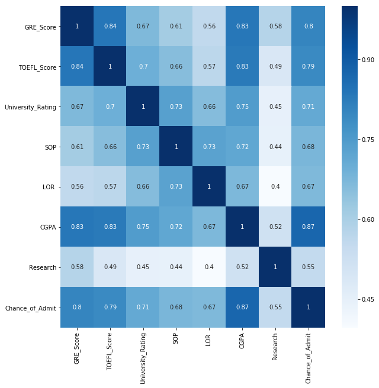

```python
fig, ax = plt.subplots(figsize=(10,10))
sns.heatmap(dataset.corr(),annot = True,cmap = 'Blues')
plt.show()
```

## Here, we have divided our dataset into Independent variables and Dependent variable.

### x conatins all the independent variable.

### y contains the dependent variable.

```python
x = dataset.iloc[:,0:7].values # iloc is used for integer-location based indexing / selection by indexing
y = dataset.iloc[:, -1].values
print("These are the independent variables of our dataset",x,sep = "\n\n",end = "\n\n\n\n")
print("This is the dependent variable of our dataset",y,sep = "\n\n",end = "\n\n\n\n")
```

[output not shown]

## This is the plotting of GRE Score vs Chance of Admit :

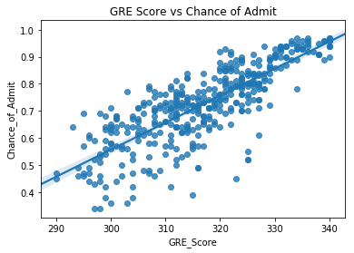

```python
sns.regplot(dataset['GRE_Score'],dataset['Chance_of_Admit']) # Plot the residuals of a linear regression model
plt.title("GRE Score vs Chance of Admit")
plt.show()
```

## This is the plotting of TOEFL Score vs Chance of Admit :

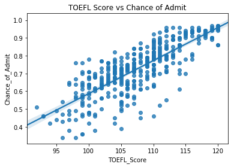

```python
sns.regplot(dataset['TOEFL_Score'],dataset['Chance_of_Admit'])
plt.title("TOEFL Score vs Chance of Admit")
plt.show()
```

## This is the plotting of SOP vs Chance of Admit :

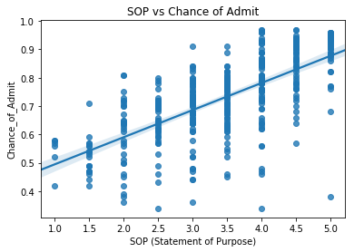

```python
sns.regplot(dataset['SOP'],dataset['Chance_of_Admit'])
plt.title("SOP vs Chance of Admit")
plt.xlabel("SOP (Statement of Purpose)")
plt.show()
```

## This the plotting of LOR vs Chance of Admit :

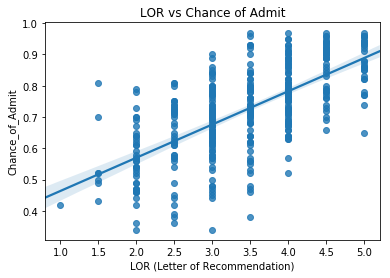

```python
l=dataset.iloc[:,4].values
sns.regplot(l,dataset['Chance_of_Admit'])
plt.title("LOR vs Chance of Admit")
plt.xlabel("LOR (Letter of Recommendation)")
plt.show()
```

## This is the plotting of CGPA vs Chance of Admit :

This is the strongest factor among all the factors which are affecting the Chance of Admit of a student.

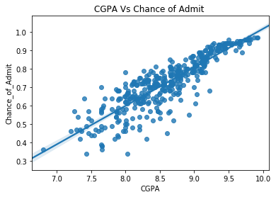

```python
sns.regplot(dataset['CGPA'],dataset['Chance_of_Admit'])
plt.title("CGPA Vs Chance of Admit ")
plt.show()
```

## This is the bar graph of those students who have done any research or not for the university before applying for the admission.

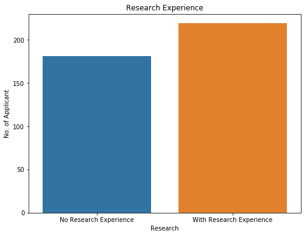

```python
plt.figure(figsize=(8,6))
R = ['No Research Experience','With Research Experience']
ypos = np.arange(len(R))
sns.countplot(dataset['Research'])
plt.title('Research Experience')
plt.ylabel('No. of Applicant')
plt.xticks(ypos,R)
plt.show()
```

## This is the bar graph of the University Rating :

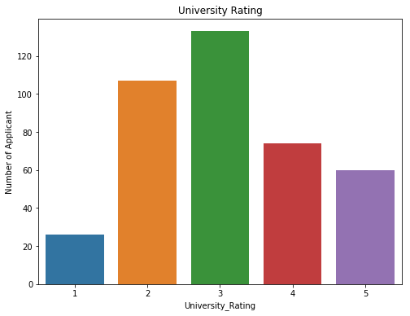

```python
plt.figure(figsize=(8,6))
U = ['1','2','3','4','5']
ypos = np.arange(len(U))
sns.countplot(dataset['University_Rating'])
plt.title('University Rating')
plt.ylabel('Number of Applicant')
plt.xticks(ypos,U)
plt.show()
```

## Now we are encoding our categorical data.

```python
labelencoder = LabelEncoder()                  #create object 1 of LabelEncoder class
labelencoder1 = LabelEncoder()                 #create object 2 of LabelEncoder class
x[:, 6] = labelencoder1.fit_transform(x[:, 6]) #fitting the labelencoder object 1 and transform the research column
x[:, 2] = labelencoder.fit_transform(x[:, 2])  #fitting the labelencoder object 2 and transform the university ranking column

onehotencoder = OneHotEncoder(categorical_features = [2]) #making dummy variable for university ranking column
x = onehotencoder.fit_transform(x).toarray()

x = x[:, 1:]    # Avoiding the Dummy Variable Trap, now x includes GRE_SCORE, TOEFL_SCORE, LOR, CGPA, Research columns
print("This is our independent variables after encoding the categorical data",x,sep = "\n\n",end = "\n\n\n\n")
```

```
This is our independent variables after encoding the categorical data

[[0.   0.   1.   ... 4.5  9.65 1.  ]
 [0.   0.   1.   ... 4.5  8.87 1.  ]
 [0.   1.   0.   ... 3.5  8.   1.  ]
 ...
 [0.   0.   1.   ... 4.5  9.45 1.  ]
 [0.   1.   0.   ... 4.   8.78 0.  ]
 [0.   0.   1.   ... 4.   9.66 1.  ]]
```

## To append the column of one's in our independent variables at starting.

## y = b0 + b1*x1 + b2*x2 ----- + bn*xn

By appending the column of one's in our independent variables we are basically replacing the x0 value with column of one's as it is required by statsmodel.formula.api, so it is done manually.

```python
x=np.append(arr = np.ones((400,1)).astype(int) , values = x , axis = 1)
print("This is our independent variables after the appending the column of one's in our dataset",x,sep = "\n\n",end = "\n\n\n\n")
```

```
This is our independent variables after the appending the column of one's in our dataset

[[1.   0.   0.   ... 4.5  9.65 1.  ]
 [1.   0.   0.   ... 4.5  8.87 1.  ]
 [1.   0.   1.   ... 3.5  8.   1.  ]
 ...
 [1.   0.   0.   ... 4.5  9.45 1.  ]
 [1.   0.   1.   ... 4.   8.78 0.  ]
 [1.   0.   0.   ... 4.   9.66 1.  ]]
```

## Now we are applying the multiple linear regression with all the variables in our Dataset.

```python
regres = sm.OLS(y, x).fit()
print(regres.summary())
```

```
                            OLS Regression Results
==============================================================================
Dep. Variable:                      y   R-squared:                       0.805
Model:                            OLS   Adj. R-squared:                  0.800
Method:                 Least Squares   F-statistic:                     160.8
Date:                Fri, 26 Jul 2019   Prob (F-statistic):          1.76e-131
Time:                        13:18:39   Log-Likelihood:                 539.15
No. Observations:                 400   AIC:                            -1056.
Df Residuals:                     389   BIC:                            -1012.
Df Model:                          10
Covariance Type:            nonrobust
==============================================================================
                 coef    std err          t      P>|t|      [0.025      0.975]
------------------------------------------------------------------------------
const         -1.2438      0.127     -9.784      0.000      -1.494      -0.994
x1            -0.0147      0.015     -0.997      0.320      -0.044       0.014
x2            -0.0093      0.016     -0.579      0.563      -0.041       0.022
x3            -0.0074      0.020     -0.375      0.708      -0.046       0.031
x4             0.0104      0.022      0.479      0.633      -0.032       0.053
x5             0.0017      0.001      2.860      0.004       0.001       0.003
x6             0.0031      0.001      2.802      0.005       0.001       0.005
x7            -0.0026      0.006     -0.470      0.639      -0.014       0.008
x8             0.0228      0.006      4.109      0.000       0.012       0.034
x9             0.1187      0.012      9.715      0.000       0.095       0.143
x10            0.0244      0.008      3.057      0.002       0.009       0.040
==============================================================================
Omnibus:                       80.839   Durbin-Watson:                   0.747
Prob(Omnibus):                  0.000   Jarque-Bera (JB):              161.236
Skew:                          -1.085   Prob(JB):                     9.73e-36
Kurtosis:                       5.229   Cond. No.                     1.34e+04
==============================================================================

Warnings:
[1] Standard Errors assume that the covariance matrix of the errors is correctly specified.
[2] The condition number is large, 1.34e+04. This might indicate that there are
strong multicollinearity or other numerical problems.
```

## Here we have applied the multiple linear regression for our model with the method of Backward Elimination.

Backward Elimination: In Backward Elimination we start with all the features and remove the least significant feature at each iteration which improves the performance of the model.

### The summary of our model like ( Accuracy, P value, Estimated error etc.) will be presented by this method.

```python
def backwardElimination(x, sl):               #function of backward elimination
    numVars = len(x[0])
    for i in range(0, numVars):
        regressor_OLS = sm.OLS(y, x).fit()
        maxVar = max(regressor_OLS.pvalues).astype(float)
        if maxVar > sl:
            for j in range(0, numVars - i):
                if (regressor_OLS.pvalues[j].astype(float) == maxVar):
                    x = np.delete(x, j, 1)
    regressor_OLS.summary()
    return x

SL = 0.05               #setting up the threshold value for backward eliminaion
x_opt = x[:,:]                               #taking all columns of x in  x_opt
x_Modeled = backwardElimination(x_opt, SL)#calling backward elimination function
x=x_Modeled                                  #remove the columns of one
regres = sm.OLS(y, x).fit()
print(regres.summary())
```

```
                            OLS Regression Results
==============================================================================
Dep. Variable:                      y   R-squared:                       0.803
Model:                            OLS   Adj. R-squared:                  0.800
Method:                 Least Squares   F-statistic:                     320.6
Date:                Fri, 26 Jul 2019   Prob (F-statistic):          2.04e-136
Time:                        13:18:42   Log-Likelihood:                 536.61
No. Observations:                 400   AIC:                            -1061.
Df Residuals:                     394   BIC:                            -1037.
Df Model:                           5
Covariance Type:            nonrobust
==============================================================================
                 coef    std err          t      P>|t|      [0.025      0.975]
------------------------------------------------------------------------------
const         -1.2985      0.117    -11.070      0.000      -1.529      -1.068
x1             0.0018      0.001      2.992      0.003       0.001       0.003
x2             0.0030      0.001      2.847      0.005       0.001       0.005
x3             0.0228      0.005      4.741      0.000       0.013       0.032
x4             0.1210      0.012     10.312      0.000       0.098       0.144
x5             0.0246      0.008      3.103      0.002       0.009       0.040
==============================================================================
Omnibus:                       87.489   Durbin-Watson:                   0.750
Prob(Omnibus):                  0.000   Jarque-Bera (JB):              179.337
Skew:                          -1.157   Prob(JB):                     1.14e-39
Kurtosis:                       5.325   Cond. No.                     1.23e+04
==============================================================================

Warnings:
[1] Standard Errors assume that the covariance matrix of the errors is correctly specified.
[2] The condition number is large, 1.23e+04. This might indicate that there are
strong multicollinearity or other numerical problems.
```

## Now we have divided our dataset into test set and training set.

```python
x_train, x_test, y_train, y_test = train_test_split(x, y, test_size = 0.2, random_state = 0)
print("This is the independent variables of the training set",x_train,sep = "\n\n",end = "\n\n\n\n")
print("This is the dependent variable of the training set",y_train,sep = "\n\n",end = "\n\n\n\n")
print("This is the independent variables of the test set",x_test,sep = "\n\n",end = "\n\n\n\n")
print("This is the dependent variable of the test set",y_test,sep = "\n\n",end = "\n\n\n\n")
```

[output not shown]

[output cut: 78 more lines]

```
 [  1.   306.   103.     3.     8.36   0.  ]
 [  1.   313.   106.     2.     8.43   0.  ]
 [  1.   334.   116.     3.5    9.54   1.  ]
 [  1.   297.    96.     1.5    7.89   0.  ]]



This is the dependent variable of the test set

[0.71 0.7  0.79 0.73 0.72 0.48 0.77 0.71 0.9  0.94 0.58 0.89 0.72 0.57
 0.78 0.42 0.64 0.84 0.63 0.72 0.9  0.83 0.57 0.47 0.85 0.67 0.44 0.54
 0.92 0.62 0.68 0.73 0.73 0.61 0.55 0.74 0.64 0.89 0.73 0.95 0.71 0.72
 0.75 0.76 0.86 0.7  0.39 0.79 0.61 0.64 0.71 0.8  0.61 0.89 0.68 0.79
 0.78 0.52 0.76 0.88 0.74 0.49 0.65 0.59 0.87 0.89 0.81 0.9  0.8  0.76
 0.68 0.87 0.68 0.64 0.91 0.61 0.69 0.62 0.93 0.43]
```

## Now we have do the feature scaling for our training and test set for the dataset.

```python
sc_x = StandardScaler()                               #create object 1 of Standard Scaler class
sc_y = StandardScaler()                               #create object 2 of Standard Scaler class
x_train = sc_x.fit_transform(x_train)                 #transform the x_train set
x_test = sc_x.transform(x_test)                       #transform the x_test set
y_train = sc_y.fit_transform(y_train.reshape(-1, 1))  #transform the y_train set
print("this the independent variables of training set after scaling the data",x_train,sep = "\n\n",end = "\n\n\n\n")
print("this the independent variables of test set after scaling the data",x_test,sep = "\n\n",end = "\n\n\n\n")
print("this the dependent variable of training set after scaling the data",y_train,sep = "\n\n",end = "\n\n\n\n")
```

[output not shown]

[output cut: 364 more lines]

```
 [ 1.47963713]
 [-0.46229178]
 [-1.15583782]
 [-0.18487337]
 [-0.18487337]
 [ 0.64738188]
 [-1.91873846]
 [ 0.57802728]
 [ 0.36996346]
 [-0.18487337]
 [-0.7397102 ]
 [ 0.9248003 ]
 [-1.91873846]
 [ 1.13286411]
 [ 0.9248003 ]]
```

## Here we have fitting the multiple linear regression to the training set.

```python
######### Fitting Multiple Linear Regression to the Training set###############
regressor = LinearRegression()      #creating object of linear Regression class
regressor.fit(x_train, y_train)     #fitting the regression model on x and y train
```

```
LinearRegression(copy_X=True, fit_intercept=True, n_jobs=None, normalize=False)
```

## This is the final step of or model .

#### Now we are predicting the test dataset after finshing of training of our model.

```python
y_pred = regressor.predict(x_test)               # predicting the x_test results
y_pred = sc_y.inverse_transform(y_pred)          # used to rescale the values from the standard scale to originl one
print("This is the predicted values corresponding to the x_test",y_pred,sep="\n\n" , end="\n\n\n\n")
```

```
This is the predicted values corresponding to the x_test

[[0.6848754 ]
 [0.68724894]
 [0.7812596 ]
 [0.61931967]
 [0.72147679]
 [0.60610544]
 [0.70524844]
 [0.64054656]
 [0.88613408]
 [0.92129774]
 [0.53765301]
 [0.87870672]
 [0.71870519]
 [0.46040509]
 [0.853735  ]
 [0.6225768 ]
 [0.64299102]
 [0.82642998]
 [0.59052208]
 [0.73513902]
 [0.87756793]
 [0.84490399]
 [0.64764889]
 [0.45061415]
 [0.78420842]
 [0.58124166]
 [0.50035353]
 [0.64165654]
 [0.88388237]
 [0.65852335]
 [0.6419275 ]
 [0.74220656]
 [0.74166238]
 [0.5565777 ]
 [0.77901768]
 [0.77180692]
 [0.6603794 ]
 [0.86137111]
```

[output cut: 27 more lines]

```
 [0.82447225]
 [0.73800425]
 [0.86266158]
 [0.76933523]
 [0.7536917 ]
 [0.60186005]
 [0.82614155]
 [0.8306678 ]
 [0.6045614 ]
 [0.93088876]
 [0.63426529]
 [0.63851346]
 [0.6473487 ]
 [0.90917078]
 [0.51383941]]
```

## Here is the Interface of our model which makes the prediction more easier for normal people just by entering some important information of student.

```python
def view():
    print("\nThe data set used have 8 columns(features) and 400 rows(observations)\n")
    print("The columns are named as GRE_score(Graduate Record Examinations) , TOEFl_score( Test of English  as a Foreign Language), University Ranking ,SOP(Satement of proof), LOR(Letter of Recommendation) ,CGPA(Cumulative Grade Point Average) ,Research(is student done a  research in any field or not) ,chance_of_Admit(Dependent variable) ")
    print("\npress 1 to view the dataset\n")
    a=int(input())
    if a==1:
        print(dataset)

def correlation():
    fig, ax = plt.subplots(figsize=(10,10))
    sns.heatmap(dataset.corr(method='pearson'),annot = True,cmap = 'Blues')
    plt.show()
def graphs():
    i1='y'
    while i1=='y':
        print("\nplease enter which graph you want to see ")
        print("press 1 for view the GRE_Score vs Chane_of_Admit garph")
        print("press 2 for view the TOEFL_Score vs Chane_of_Admit garph")
        print("press 3 for view the LOR vs Chane_of_Admit garph")
        print("press 4 for view the CGPA vs Chane_of_Admit garph")
        print("press 5 for view the how many applicant done any research or not")
        n1=int(input())
        if n1==1:
            sns.regplot(dataset['GRE_Score'],dataset['Chance_of_Admit'])
            plt.title("GRE Score vs Chance of Admit")
            plt.show()
        elif n1==2:
            sns.regplot(dataset['TOEFL_Score'],dataset['Chance_of_Admit'])
            plt.title("TOEFL Score vs Chance of Admit")
            plt.show()
        elif n1==3:
            l=dataset.iloc[:,4].values
            sns.regplot(l,dataset['Chance_of_Admit'])
            plt.title("LOR vs Chance of Admit")
            plt.xlabel("LOR")
            plt.show()
        elif n1==4:
            sns.regplot(dataset['CGPA'],dataset['Chance_of_Admit'])
            plt.title("CGPA Vs Chance of Admit ")
            plt.show()

        elif n1==5:
            plt.figure(figsize=(8,6))
            R = ['No Research Experience','With Research Experience']
            ypos = np.arange(len(R))
            sns.countplot(dataset['Research'])
            plt.title('Research Experience')
            plt.ylabel('No. of Applicant')
            plt.xticks(ypos,R)
            plt.show()

        print("do you want to view other graph then press y otherwise press N/n ")
        i1=input()

def results():
    print("\nThe test set result is\n")
    print(y_pred)
    sns.regplot(y_pred,y_test)
    plt.title("prediction vs test result")
    plt.xlabel("prediction of test set")
    plt.ylabel("test set values")
    plt.show()

def predic():
    p=[1]
    print("\nFor predicting a new value you have to enter some information \n like GRE_Score , TOEFL_Score ,LOR , CGPA and Research of the student\n ")
    p.append(int(input("Enter the GRE_Score of the student\n")))
    p.append(int(input("Enter the TOEFL_Score of the student\n")))
    p.append(float(input("Enter the LOR information of the student\n")))
    p.append(float(input("Enter the CGPA of the student\n")))
    p.append(int(input("Press 1 if student done a research and 0 if student did not done a research\n")))
    p = np.array(p).reshape(1,6)
    p[:, 5] = labelencoder1.transform(p[:, 5])
    p = sc_x.transform(p)
    p_pred = regressor.predict(p)
    p_pred = sc_y.inverse_transform(p_pred)
    print("the result of prediction is ",p_pred)

def summ():
    print("\nThe dataset include 8 variables")
    print("Based on the backward Eloimination method of the independent variables ")
    print("We identify some features which have p value less than 0.05 ")
    print("These features are GRE_Score ,TOEFL_Score,LOR ,CGPA ,Research")
    print("The summary of fitting these feature with dependent variable is as follows\n")
    print(regres.summary())

print("\n This programm is for predicting that the student will get the admission in the college or not based on pevious data\n")
i='y'
while i=='y':
    print("enter your choice ")
    print("press 1 for view the dataset(train + test)")
    print("press 2 for view the correlation table between the features of dataset")
    print("press 3 for view the graphs between independent and dependent variables")
    print("press 4 for view the test set result")
    print("press 5 for predicting a new value")
    print("press 6 for view some essential information")
    n=int(input())
    if n==1:
        view()
    elif n==2:
        correlation()
    elif n==3:
        graphs()
    elif n==4:
        results()
    elif n==5:
        predic()
    else:
        summ()
    print("\ndo you want to view another things in the model then press y otherwise press N/n ")
    i=input()
```

```
 This programm is for predicting that the student will get the admission in the college or not based on pevious data

enter your choice
press 1 for view the dataset(train + test)
press 2 for view the correlation table between the features of dataset
press 3 for view the graphs between independent and dependent variables
press 4 for view the test set result
press 5 for predicting a new value
press 6 for view some essential information
5

For predicting a new value you have to enter some information
 like GRE_Score , TOEFL_Score ,LOR , CGPA and Research of the student

Enter the GRE_Score of the student
314
Enter the TOEFL_Score of the student
103
Enter the LOR information of the student
3
Enter the CGPA of the student
8.21
Press 1 if student done a research and 0 if student did not done a research
0
the result of prediction is  [[0.6368447]]

do you want to view another things in the model then press y otherwise press N/n
n
```